# Final NB

## Imports

```python
import pandas as pd
import numpy as np
import matplotlib.pyplot as plt
from IPython.display import Image
import seaborn as sns
```

```python
import pyarrow as pa
from datasets import Dataset
from datasets import load_dataset
from datasets import DatasetDict
```

```python
from umap import UMAP
from sklearn.preprocessing import MinMaxScaler
from transformers import AutoTokenizer
```

```python
import torch
import torch.nn.functional as F
from transformers import AutoModel
```

```python
from sklearn.metrics import f1_score,classification_report
from sklearn.preprocessing import LabelEncoder
from sklearn.metrics import ConfusionMatrixDisplay, confusion_matrix
from transformers import AutoModelForSequenceClassification
from transformers import Trainer, TrainingArguments
from sklearn.metrics import accuracy_score,f1_score
from transformers import Trainer
from torch.nn.functional import cross_entropy
from transformers import pipeline
```

## Helper Functions

```python
def tokenize(batch):
    '''This function applies tokenizer to a batch of examples; padding=True will pad the examples with
    zeros to the size of the longest one in a batch, and truncation=True will truncate the examples
    to the model's maximum context size.'''
    return tokenizer(batch["Claim Description"],padding=True, truncation = True)
```

```python
def extract_hidden_states(batch):

    # Place model inputs on the GPU
    inputs = {k:v.to(device) for k,v in batch.items() if k in tokenizer.model_input_names}

    # Extract last hidden states
    with torch.no_grad():
        last_hidden_state = model(**inputs).last_hidden_state

    # Return vector for [CLS] token, and putting it back to CPU
    return {"hidden_state": last_hidden_state[:,0].cpu().numpy()}
```

```python
def plot_confusion_matrix(y_preds,y_true, labels):
    cm = confusion_matrix(y_true, y_preds, normalize="true")
    fig,ax = plt.subplots(figsize=(20,6))
    disp = ConfusionMatrixDisplay(confusion_matrix =cm, display_labels= labels)
    disp.plot(cmap="Blues", values_format=".2f", ax=ax, colorbar=False)
    plt.title("Normalized Confusion Matrix")
    plt.show()
```

```python
def compute_metrics(pred):
    labels = pred.label_ids
    preds = pred.predictions.argmax(-1)
    f1 = f1_score(labels,preds,average="weighted")
    acc = accuracy_score(labels,preds)
    return {"accuracy":acc,"f1":f1}
```

```python
def filter_high_frequency_classes(data,col,pct):
    # Get value counts for each category in 'Coverage Code'
    coverage_counts =data[col].value_counts(normalize=True)*100

    # Filter to retain only categories with counts greater than 1 pct
    high_frequency_class = coverage_counts[coverage_counts > pct].index

    return high_frequency_class
```

```python
def label_int2str(x,label_mapping):
    label_mapping_rev={}
    for k,v in label_mapping.items():
        label_mapping_rev[v]=k
    return label_mapping_rev[x]
```

```python
def str2int(x,label_mapping):
    return label_mapping[x]
```

## Loading and Preparing Data

```python
df = pd.read_csv(r'C:\Users\abhij\Desktop\NewGen\Gallagher\Dataset_Public.csv')
```

```python
col = 'Coverage Code'
pct = 1
high_frequency_coverage_code = filter_high_frequency_classes(df,col,pct)
print(f"`{col}` having frequency % more than {pct}% are:\n\n{high_frequency_coverage_code.values} ")
```

```
`Coverage Code` having frequency % more than 1% are:

['AD' 'GB' 'GD' 'AP' 'AB' 'AL' 'PA' 'PB' 'RB' 'NS']
```

```python
pct_d = sum(df[df[col].isin(filter_high_frequency_classes(df,col,pct))][col].value_counts()/df.shape[0]*100)
df[df[col].isin(filter_high_frequency_classes(df,col,pct))][col].value_counts()/df.shape[0]*100
```

```
Coverage Code
AD    26.540247
GB    17.446920
GD    14.076373
AP    12.176952
AB     7.407272
AL     5.460379
PA     4.676822
PB     2.911993
RB     2.740362
NS     1.226981
Name: count, dtype: float64
```

```python
print(pct_d,"%")
```

```
94.66430173717981 %
```

- Above categories of `Coverage Code` account close to **95%** of the data. Therefore, other categories can be grouped under common name as **"others"**

```python
col ='Accident Source'
pct = 1
high_frequency_accident_source = filter_high_frequency_classes(df,col,pct)
print(f"`{col}` having frequency % more than {pct}% are:\n\n{high_frequency_accident_source.values} ")
```

```
`Accident Source` having frequency % more than 1% are:

['Alleged Negligent Act' 'Sideswipe or lane change'
 'Struck vehicle in rear' 'Not Otherwise Classified'
 'Struck animal or object' 'Struck parked vehicle'
 'Backed into vehicle or object' 'Intersection accident'
 'Our vehicle struck in rear' 'Alleged improper maintenance - other'
 'Pothole' 'e-Commerce' 'Alleged foreign object in product'
 'Vehicle Accident' 'Cart' 'Windshield' 'Ground/floor'
 'Alleged damage to property of others' 'Human Action, NOC'
 'Struck/pulled down wires' 'Alleged contamination or spoilage'
 'Alleged design flaw, defect']
```

```python
pct_d = sum(df[df[col].isin(filter_high_frequency_classes(df,col,pct))][col].value_counts()/df.shape[0]*100)
df[df[col].isin(filter_high_frequency_classes(df,col,pct))][col].value_counts()/df.shape[0]*100
```

[output not shown]

```python
print(pct_d,"%")
```

```
65.1259846627367 %
```

- Above categories of `Accident Source` account to **65.13%** of the data. Therefore, other categories can be grouped under common name as **"others"**

```python
col = 'Accident Source'

for i,cat in enumerate(df[col].unique()):
    if len(df[df[col]==cat]['Coverage Code'].unique())==1:
        pass
    else:
        print(i,cat)

print(df['Accident Source'].nunique())
```

```
0 Struck pedestrian, bicycle
1 Elevator/Escalator
2 Sideswipe or lane change
3 Food Product
4 Struck vehicle in rear
5 Backed into vehicle or object
6 Alleged improper maintenance - other
7 Alleged Negligent Act
8 Fall - other falls
9 Struck animal or object
10 Malicious Mischief
11 Plumbing,Heating,AC,Discharge,Overflowing
12 Stairs
13 Reversing/Manoeuvring
14 Excavation, trench, tunnel
```

[output cut: 295 more lines]

### Only keeping high frequency categories and assigning rest to others

```python
def assign_others(cat,high_frequency_cat):
    if cat in high_frequency_cat:
        return cat
    else:
        return 'other'
```

```python
cat = 'RX'
high_frequency_cat = high_frequency_coverage_code
assign_others(cat,high_frequency_cat)
```

```
'other'
```

```python
df['Coverage Code Merged'] = df['Coverage Code'].apply(lambda x:assign_others(x,high_frequency_coverage_code))
df['Accident Source Merged'] = df['Accident Source'].apply(lambda x:assign_others(x,high_frequency_accident_source))
```

### Label Encoding the Merged Columns

```python
# Assume `df` is your DataFrame and `categorical_column` is the column to encode
coverage_code_le = LabelEncoder()
df['Coverage Code Encoded'] = coverage_code_le.fit_transform(df['Coverage Code Merged'])

# Mapping of labels to integers
coverage_code_label_mapping = dict(zip(coverage_code_le.classes_, coverage_code_le.transform(coverage_code_le.classes_)))
print(coverage_code_label_mapping)
```

```
{'AB': 0, 'AD': 1, 'AL': 2, 'AP': 3, 'GB': 4, 'GD': 5, 'NS': 6, 'PA': 7, 'PB': 8, 'RB': 9, 'other': 10}
```

```python
# Assume `df` is your DataFrame and `categorical_column` is the column to encode
accident_source_le = LabelEncoder()
df['Accident Source Encoded'] = accident_source_le.fit_transform(df['Accident Source Merged'])

# Mapping of labels to integers
accident_source_label_mapping = dict(zip(accident_source_le.classes_, accident_source_le.transform(accident_source_le.classes_)))
print(accident_source_label_mapping)
```

```
{'Alleged Negligent Act': 0, 'Alleged contamination or spoilage': 1, 'Alleged damage to property of others': 2, 'Alleged design flaw, defect': 3, 'Alleged foreign object in product': 4, 'Alleged improper maintenance - other': 5, 'Backed into vehicle or object': 6, 'Cart': 7, 'Ground/floor': 8, 'Huma…
```

### Splitting data into train and test

```python
data = df.copy()
```

```python
dataset = df[['Claim Description','Coverage Code Merged']]
```

```python
dataset['label'] = df['Coverage Code Encoded']
dataset  = dataset[dataset['Claim Description'].notna()]
```

```python
hg_dataset = Dataset(pa.Table.from_pandas(dataset))
hg_dataset = hg_dataset.remove_columns("__index_level_0__")
```

```python
train_dataset, validation_dataset= hg_dataset.train_test_split(test_size=0.2).values()
```

```python
dataset = DatasetDict({'train': train_dataset, 'val': validation_dataset})
```

```python
dataset
```

```
DatasetDict({
    train: Dataset({
        features: ['Claim Description', 'Coverage Code Merged', 'label'],
        num_rows: 153170
    })
    val: Dataset({
        features: ['Claim Description', 'Coverage Code Merged', 'label'],
        num_rows: 38293
    })
})
```

### EDA Overview

```python
df = pd.DataFrame(dataset['train'][:])
```

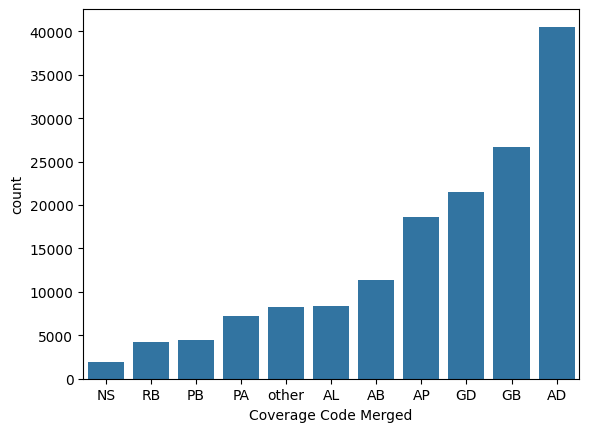

```python
counts = df['Coverage Code Merged'].value_counts().sort_values(ascending=True).index.to_list()
sns.countplot(data=df,x="Coverage Code Merged",orient="y",order=counts)
plt.show()
```

### Maximum context size

- Transformer models have a maximum input sequence length that is referred to as the *maximum context size*.
- For applications using **DistilBERT**, the maximum context size is 512 tokens, which amounts to a few paragraphs of text.

```python
df["Words Per review"] = df["Claim Description"].str.split().apply(len)
```

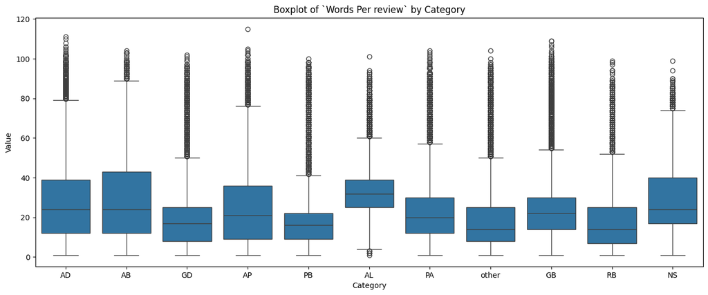

```python
# Plotting the boxplot
plt.figure(figsize=(16, 6))
sns.boxplot(x='Coverage Code Merged', y='Words Per review', data=df)
plt.title('Boxplot of `Words Per review` by Category')
plt.xlabel('Category')
plt.ylabel('Value')
plt.show()
```

- From the plot we see that for each emotion, most descriptions are around 15-40 words long and the longest descriptions are well below *DistilBERT's* maximum context size.
- Texts that are longer than a model's context size needs to be truncated, which can lead to a loss in performance, if the truncated text contains crucial information.

### Tokenization

- **Tokenzation** is the step of breaking down a string into the atomic units used in the model.
- **Numericalization** is the process of converting a character into an integer.

```python
model_ckpt = "distilbert-base-uncased"
tokenizer = AutoTokenizer.from_pretrained(model_ckpt)
```

- The **AutoTokenizer** class belongs to a larger set of *"auto"* classes whose job is to automatically retrieve the model's configuration, pretrained weights, or vocabulary from the name of the checkpoint.

```python
text = dataset['train'][1]['Claim Description']
```

```python
print(text)
encoded_text = tokenizer(text)
print(encoded_text)
```

```
THE OV MADE A LEFT TURN AND COLLIDED WITH THE IV, THAT WAS        ATTEMPTING TO PASS IT ON THE ROAD. THE IV THEN STRUCK A WALL. THE IV INCURRED FRONT END DAMAGE. THE DAMAGE TO THE OV IS UNKNOWN AND THE WALL INCURRED NO DAMAGE. THERE WERE NO INJURIES REPORTED.
{'input_ids': [101, 1996, 1051, 2615, 2081, 1037, 2187, 2735, 1998, 17745, 2007, 1996, 4921, 1010, 2008, 2001, 7161, 2000, 3413, 2009, 2006, 1996, 2346, 1012, 1996, 4921, 2059, 4930, 1037, 2813, 1012, 1996, 4921, 22667, 2392, 2203, 4053, 1012, 1996, 4053, 2000, 1996, 1051, 2615, 2003, 4242, 1998, 19…
```

- We can convert the **input_ids** back into tokens by using the tokenizer's **convert_ids_to_tokens()** method:

```python
tokens = tokenizer.convert_ids_to_tokens(encoded_text.input_ids)
print(tokens)
```

```
['[CLS]', 'the', 'o', '##v', 'made', 'a', 'left', 'turn', 'and', 'collided', 'with', 'the', 'iv', ',', 'that', 'was', 'attempting', 'to', 'pass', 'it', 'on', 'the', 'road', '.', 'the', 'iv', 'then', 'struck', 'a', 'wall', '.', 'the', 'iv', 'incurred', 'front', 'end', 'damage', '.', 'the', 'damage', …
```

#### Tokenizing the Whole Dataset

```python
tokenize(dataset['train'][:3])
```

```
{'input_ids': [[101, 8824, 4357, 2007, 4062, 3936, 2008, 2256, 4062, 2001, 3030, 1012, 1051, 2615, 2699, 2000, 2735, 2157, 1010, 3495, 1999, 2392, 1997, 2256, 4316, 1010, 8478, 1996, 2392, 2187, 19028, 1998, 21519, 1010, 4786, 4053, 2000, 2256, 4316, 1012, 2062, 2592, 2000, 3582, 2043, 2009, 4150, 2…
```

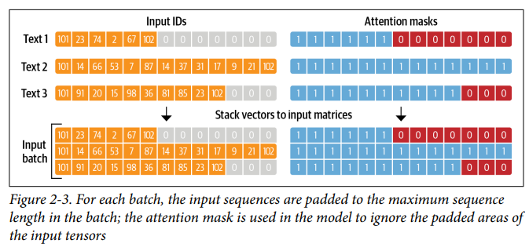

```python
Image(filename=r'C:\Users\abhij\Desktop\Transformers\transformers\Notebooks\Gallhagher_AJG\image1.png')
```

```python
# Tokenizing the train dataset
description_encoded = dataset['train'].map(tokenize, batched=True, batch_size=512)
```

```python
# Tokenizing the validation dataset
description_encoded_valid=  dataset['val'].map(tokenize, batched=True, batch_size=512)
```

### Training a Text Classifier

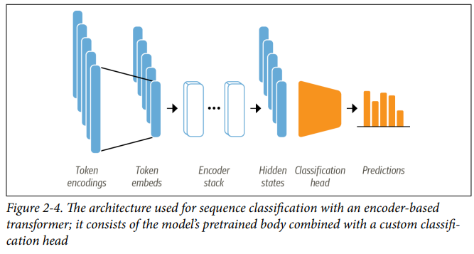

```python
Image(filename=r'C:\Users\abhij\Desktop\Transformers\transformers\Notebooks\Gallhagher_AJG\image2.png')
```

- Classification using **DistilBERT**:
  - First, the text is tokenized and represented as one-hot vectors called **token encodings**.
  - Second, **token encodings** are converted into **token embeddings**, which are vectors living in lower dimensional space.
  - Third, **token embeddings** are then passed through the encoder block layers to yield a **hidden state** for each input token.
  - Last step, for the pretraining objective of language modeling, hidden state is fed to a layer that predicts the masked input tokens.
    - For the **classification task**, we replace the language modeling layer with a classification layer
- Options to train a model on a dataset:
  - **Feature Extraction**: Use the hidden states as features and just train a classifier on them, without modifying the pretrained model.
  - **Fine-tuning**: Train the whole model end-to-end, which also updates the parameters of the pretrained model.

### Transformers as Feature Extractors

- We freeze the body's weights during training and use the hidden states as features for the classifier.
- This method is especially convenient if GPUs are unavailable, since the hidden states only need to be precomputed once.

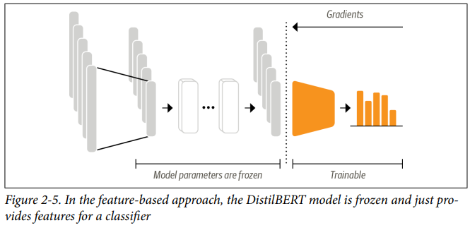

```python
Image(filename=r'C:\Users\abhij\Desktop\Transformers\transformers\Notebooks\Gallhagher_AJG\image3.png')
```

##### Using pretrained models

- **AutoModel** has a **from_pretrained()** method to load the weights of a pretrained model.
- **AutoModel** class converts the token encodings to embeddings, and then feeds them through the encoder stack to return the hidden states.

```python
model_ckpt = "distilbert-base-uncased"
device = torch.device("cuda" if torch.cuda.is_available() else "cpu")
model = AutoModel.from_pretrained(model_ckpt).to(device)
```

```python
text = "this is a test"
inputs = tokenizer(text, return_tensors="pt")
print(f"Input tensor shape: {inputs['input_ids'].size()}")
# resulting tensor has the shape [batch_size, n_tokens]
```

```
Input tensor shape: torch.Size([1, 6])
```

```python
# Placing the encodings on the same device as the model and pass the inputs as follows:
inputs = {k:v.to(device) for k,v in inputs.items()}
with torch.no_grad():
    outputs = model(**inputs)
print(outputs)
```

```
BaseModelOutput(last_hidden_state=tensor([[[-0.1565, -0.1862,  0.0528,  ..., -0.1188,  0.0662,  0.5470],
         [-0.3575, -0.6484, -0.0618,  ..., -0.3040,  0.3508,  0.5221],
         [-0.2772, -0.4459,  0.1818,  ..., -0.0948, -0.0076,  0.9958],
         [-0.2841, -0.3917,  0.3753,  ..., -0.2151, -0.1173,  1.0526],
         [ 0.2661, -0.5094, -0.3180,  ..., -0.4203,  0.0144, -0.2149],
         [ 0.9441,  0.0112, -0.4714,  ...,  0.1439, -0.7288, -0.1619]]],
       device='cuda:0'), hidden_states=None, attentions=None)
```

```python
outputs.last_hidden_state.size()
# [batch_size,n_tokens,hidden_dim]
```

```
torch.Size([1, 6, 768])
```

- A 768- dimensional vector is returned for each of the 6 input tokens
- For classification tasks, it is common practice to just use the hidden state associated with the **[CLS]** token as the input feature. Since this token appears at the start of each sequence, we can extract it by simply indexing into *outputs.last_hidden_state* as follows:

```python
outputs.last_hidden_state[:,0].size()
```

```
torch.Size([1, 768])
```

- The **map()** method requires the processing function to return Python or NumPy objects when we're using batched inputs.
- Since our model expects *tensors* as inputs, the next thing to do is convert the **input_ids** and **attention_mask** columns to the **"torch"** format, as follows:

```python
description_encoded.set_format("torch", columns = ["input_ids","attention_mask","label"])
description_hidden = description_encoded.map(extract_hidden_states, batched=True, batch_size=32)
```

```python
description_encoded_valid.set_format("torch", columns = ["input_ids","attention_mask","label"])
description_encoded_valid_hidden = description_encoded_valid.map(extract_hidden_states, batched=True, batch_size=32)
```

```python
torch.cuda.empty_cache()
```

### Visualizing the dataset

- Since, visualizing the hidden states in 768 dimensions is tricky, we'll use the powerful **UMAP** algorithm to project the vectors down to 2D.
  - **UMAP** works best when the features are scaled to lie in the [0,1] interval.

```python
X_train = np.array(description_hidden["hidden_state"])
y_train = np.array(description_hidden["label"])
X_valid = np.array(description_encoded_valid_hidden["hidden_state"])
y_valid = np.array(description_encoded_valid_hidden["label"])

print(X_train.shape, X_valid.shape)
```

```
(153170, 768) (38293, 768)
```

```python
# Scale features to [0,1] range
X_scaled = MinMaxScaler().fit_transform(X_train[:20000])

# Initialize and fit UMAP
mapper = UMAP(n_components=2, metric = "cosine").fit(X_scaled)

# Create a DataFrame of 2D embeddings
df_emb = pd.DataFrame(mapper.embedding_, columns = ["X","Y"])
df_emb["label"]= y_train[:20000]
```

#### Plotting the density of points for each category separately:

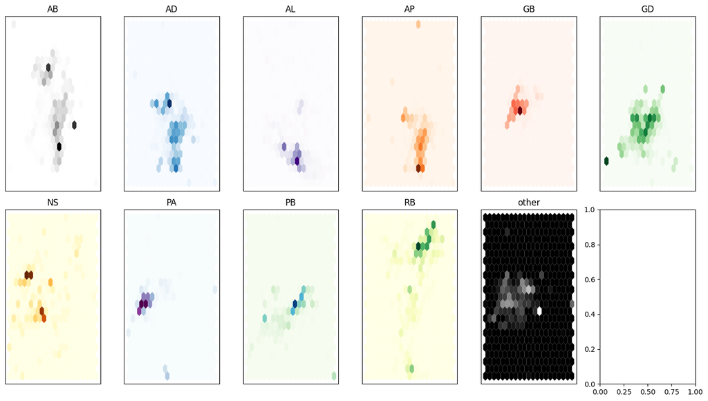

```python
fig, axes = plt.subplots(2, 6, figsize=(14, 8))  # Adjusted layout for 11 categories
axes = axes.flatten()
cmaps = ["Greys", "Blues", "Purples", "Oranges", "Reds", "Greens", "YlOrBr", "BuPu", "GnBu", "YlGn", "gray"]
# Inverting dictionary to use values for indexing
label_mapping_inverted = {v: k for k, v in coverage_code_label_mapping.items()}


# Iterate over each label and cmap
for i, (label_code, cmap) in enumerate(zip(label_mapping_inverted.keys(), cmaps)):
    label_name = label_mapping_inverted[label_code]
    df_emb_sub = df_emb.query(f"label == {label_code}")

    # Plotting hexbin for each category
    axes[i].hexbin(df_emb_sub["X"], df_emb_sub["Y"], cmap=cmap, gridsize=20, linewidths=(0,))
    axes[i].set_title(label_name)
    axes[i].set_xticks([])
    axes[i].set_yticks([])

plt.tight_layout()
plt.show()
```

### Using DistilBERT as a feature extractor and ML models as a classifier

##### Logistic Regression

```python
from sklearn.linear_model import LogisticRegression
```

```python
%%time
# Set up logistic regression with softmax for multi-class classification
lr_clf = LogisticRegression(max_iter=1000, multi_class='multinomial', solver='lbfgs')
lr_clf.fit(X_train, y_train)

# Calculate accuracy
accuracy = lr_clf.score(X_valid, y_valid)

# Predict on validation set
y_pred = lr_clf.predict(X_valid)

# Calculate F1-score
f1 = f1_score(y_valid, y_pred, average='weighted')  # use 'macro' for unweighted average across classes

print(f"Validation Accuracy: {accuracy}")
print(f"Validation F1 Score: {f1}")
```

```
Validation Accuracy: 0.69320763586034
Validation F1 Score: 0.6780709162715873
CPU times: total: 14min 49s
Wall time: 4min 38s
```

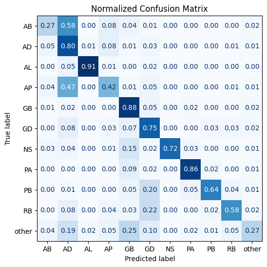

```python
y_preds = lr_clf.predict(X_valid)
plot_confusion_matrix(y_preds,np.array(dataset['val']['label']),coverage_code_label_mapping.keys())
```

##### XGBoost

```python
from xgboost import XGBClassifier
```

```python
%%time

# Initialize XGBoost classifier for multi-class classification
xgb_clf = XGBClassifier(n_estimators=100, objective="multi:softmax", num_class=11, device=device)

# Train the model
xgb_clf.fit(X_train, y_train)

# Calculate accuracy
accuracy = xgb_clf.score(X_valid, y_valid)

# Predict on validation set
y_pred = xgb_clf.predict(X_valid)

# Calculate F1-score
f1 = f1_score(y_valid, y_pred, average='weighted')  # use 'macro' for unweighted average across classes

print(f"Validation Accuracy: {accuracy}")
print(f"Validation F1 Score: {f1}")
```

```
Validation Accuracy: 0.6785574386963675
Validation F1 Score: 0.6629680807237487
CPU times: total: 2min 53s
Wall time: 2min 33s
```

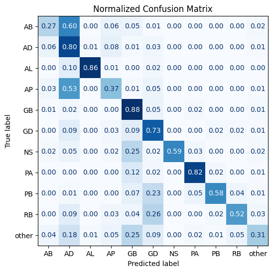

```python
plot_confusion_matrix(y_pred,np.array(dataset['val']['label']),coverage_code_label_mapping.keys())
```

### Using SMOTE-Tomek for Imbalance Correction

```python
from imblearn.combine import SMOTETomek
```

```python
%%time
# Create an instance of SMOTETomek
smote_tomek = SMOTETomek(random_state=42)

# Fit and resample the training data
X_resampled, y_resampled = smote_tomek.fit_resample(X_train, y_train)

# Print the shapes of the original and resampled datasets
print("Original training set shape:", X_train.shape, y_train.shape)
print("Resampled training set shape:", X_resampled.shape, y_resampled.shape)

# Optionally, you can also check the distribution of classes in the resampled dataset
unique, counts = np.unique(y_resampled, return_counts=True)
print("Class distribution after SMOTETomek:", dict(zip(unique, counts)))
```

```
Original training set shape: (153170, 768) (153170,)
Resampled training set shape: (445182, 768) (445182,)
Class distribution after SMOTETomek: {0: 40429, 1: 40297, 2: 40541, 3: 40320, 4: 40510, 5: 40485, 6: 40541, 7: 40541, 8: 40541, 9: 40514, 10: 40463}
CPU times: total: 3h 4min 19s
Wall time: 49min 25s
```

##### Logistic Regression

```python
%%time
# Set up logistic regression with softmax for multi-class classification
lr_clf = LogisticRegression(max_iter=1000, multi_class='multinomial', solver='lbfgs')
lr_clf.fit(X_resampled, y_resampled)

# Calculate accuracy
accuracy = lr_clf.score(X_valid, y_valid)

# Predict on validation set
y_pred = lr_clf.predict(X_valid)

# Calculate F1-score
f1 = f1_score(y_valid, y_pred, average='weighted')  # use 'macro' for unweighted average across classes

print(f"Validation Accuracy: {accuracy}")
print(f"Validation F1 Score: {f1}")
```

```
Validation Accuracy: 0.6273731491395295
Validation F1 Score: 0.63529173521755
CPU times: total: 23min 53s
Wall time: 24min 54s
```

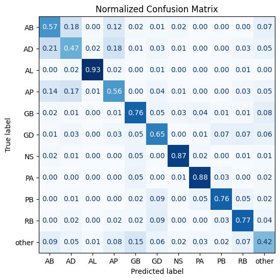

```python
plot_confusion_matrix(y_pred,np.array(dataset['val']['label']),coverage_code_label_mapping.keys())
```

##### XGBoost

```python
%%time

# Initialize XGBoost classifier for multi-class classification
xgb_clf = XGBClassifier(n_estimators=100, objective="multi:softmax", num_class=11, device=device)

# Train the model
xgb_clf.fit(X_resampled, y_resampled)

# Calculate accuracy
accuracy = xgb_clf.score(X_valid, y_valid)

# Predict on validation set
y_pred = xgb_clf.predict(X_valid)

# Calculate F1-score
f1 = f1_score(y_valid, y_pred, average='weighted')  # use 'macro' for unweighted average across classes

print(f"Validation Accuracy: {accuracy}")
print(f"Validation F1 Score: {f1}")
```

```
Validation Accuracy: 0.6448959339827123
Validation F1 Score: 0.6474368330812256
CPU times: total: 6min
Wall time: 5min 15s
```

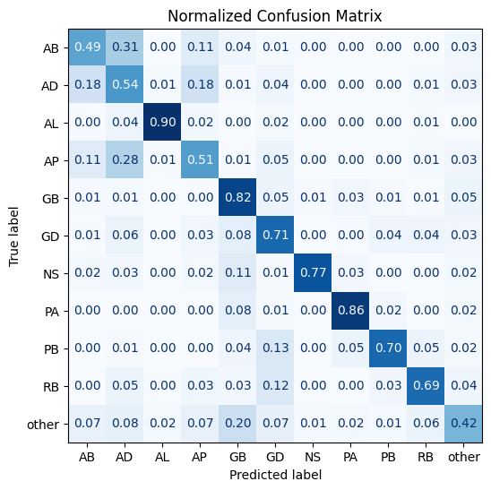

```python
plot_confusion_matrix(y_pred,np.array(dataset['val']['label']),coverage_code_label_mapping.keys())
```

### Fine-Tuning a pre-trained transformer model

- **AutoModel** vs **AutoModelForSequenceClassification**
  - The difference is that **AutoModelForSequenceClassification** model has a classification head on top of the pretrained model outputs, which can be easily trained with the base model.

```python
from transformers import AutoModelForSequenceClassification
```

```python
torch.cuda.empty_cache()
device = torch.device("cuda" if torch.cuda.is_available() else "cpu")
print("Device: ",device)
```

```
Device:  cuda
```

```python
model_ckpt
num_labels = 11
model = (AutoModelForSequenceClassification.from_pretrained(model_ckpt,
                                                           num_labels=num_labels).to(device))
```

```
Some weights of DistilBertForSequenceClassification were not initialized from the model checkpoint at distilbert-base-uncased and are newly initialized: ['classifier.bias', 'classifier.weight', 'pre_classifier.bias', 'pre_classifier.weight']
You should probably TRAIN this model on a down-stream task to be able to use it for predictions and inference.
```

```python
batch_size = 64
logging_steps = description_encoded.num_rows // batch_size
model_name = f"{model_ckpt}-finetuned-description"

training_args = TrainingArguments(
    output_dir=model_name,
    num_train_epochs=10,
    learning_rate=2e-5,
    per_device_train_batch_size=batch_size,
    per_device_eval_batch_size=batch_size,
    weight_decay=0.01,
    evaluation_strategy="steps",
    save_steps=1000,
    save_strategy='steps', # we cannot set it to "no". Otherwise, the model cannot guess the best checkpoint.
    eval_steps=1000,
    disable_tqdm=False,
    logging_steps=logging_steps,
    log_level="error",
    report_to="none",
    load_best_model_at_end = True,
    save_total_limit=3,
    use_cpu=False,
    no_cuda=False
)
```

```python
trainer = Trainer(
    model=model,
    args=training_args,
    compute_metrics=compute_metrics,
    train_dataset=description_encoded,
    eval_dataset=description_encoded_valid,
    tokenizer=tokenizer,
)
```

```python
# trainer.train()
```

- I've trained this model on GPU on colab as it provides better GPU, also training the BERT model on local notebook would take up too much time and memory.

```python
torch.cuda.empty_cache()
```

```python
save_path = r'C:\Users\abhij\Desktop\Transformers\transformers\Notebooks\Gallhagher_AJG\results\model1'

model = AutoModelForSequenceClassification.from_pretrained(save_path, return_dict=True)
tokenizer = AutoTokenizer.from_pretrained(save_path)
```

```python
trainer = Trainer(
    model=model.to(device),
    args=training_args,
    compute_metrics=compute_metrics,
    train_dataset=description_encoded,
    eval_dataset=description_encoded_valid,
    tokenizer=tokenizer,

)
```

```python
preds_output = trainer.predict(description_encoded_valid)
preds_output.metrics
```

```
{'test_loss': 0.4577873945236206,
 'test_model_preparation_time': 0.0038,
 'test_accuracy': 0.8335466012064868,
 'test_f1': 0.8286848515749564,
 'test_runtime': 301.3492,
 'test_samples_per_second': 127.072,
 'test_steps_per_second': 1.988}
```

```python
y_pred = np.argmax(preds_output.predictions, axis=1)
```

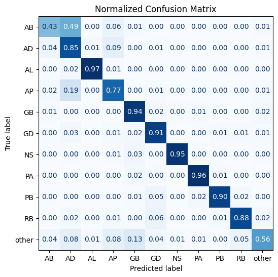

```python
plot_confusion_matrix(y_pred,np.array(dataset['val']['label']),coverage_code_label_mapping.keys())
```

```python
print(classification_report(y_valid,y_pred,target_names=coverage_code_label_mapping.keys()))
```

```
              precision    recall  f1-score   support

          AB       0.67      0.43      0.52      2774
          AD       0.77      0.85      0.81     10266
          AL       0.95      0.97      0.96      2115
          AP       0.73      0.77      0.75      4631
          GB       0.93      0.94      0.94      6746
          GD       0.92      0.91      0.92      5411
          NS       0.89      0.95      0.92       466
          PA       0.92      0.96      0.94      1781
          PB       0.91      0.90      0.90      1081
          RB       0.81      0.88      0.84      1046
       other       0.76      0.56      0.64      1976

    accuracy                           0.83     38293
   macro avg       0.84      0.83      0.83     38293
weighted avg       0.83      0.83      0.83     38293
```